## But wait…

The Ewoks say it’s unsafe to land. Booo… Sounds like the Empire is checking all ships for licenses.

Lucky for us there is some good news. They say for a small ship like ours, it is possible to land undetected. But we’ll have to put down right-dab in the middle of the 3 northern outposts.

> Are you up for a challenge data droid?

Either way, let’s make a map to see what we’re up against. To help, our comrades sent along the coordinates of the Empire’s outposts. Guess what the first step is? That’s right. Time to add a new package.

# Reading coordinates

To read coordinates stored in a CSV or Excel spreadsheet, we can read them into R with our usual friends:

- **readr**’s `read_csv()` for CSV files
- **readxl**’s `read_excel()` for Excel files

## Give it a try

```r
outposts <- read_csv("data/endor_outposts.csv")
```

### Take a look inside

```r
outposts
```

```
## # A tibble: 3 × 3
##   ID      lat  long
##   <chr> <dbl> <dbl>
## 1 1NO    36.7 -119.
## 2 1NL    36.6 -119.
## 3 3NB    36.6 -119.
```

```r
glimpse(outposts)
```

```
## Rows: 3
## Columns: 3
## $ ID   <chr> "1NO", "1NL", "3NB"
## $ lat  <dbl> 36.65520, 36.58375, 36.59790
## $ long <dbl> -118.8469, -118.8195, -118.9022
```

To make a quick map, use ggplot and add `+ geom_point()`.

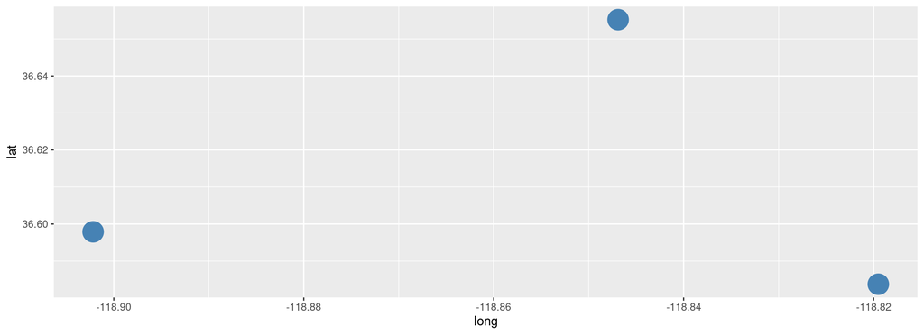

```r
library(ggplot2)

ggplot(outposts, aes(x = long, y = lat)) +
  geom_point(size = 8, color = "steelblue")
```

## Where’s the center point?

> **Hint:** How would you find the halfway point between two points?

- Set the new `lat` column to the center of all the `lat`’s
- Set the new `long` column to the center of all the `long`’s.

These will be the coordinates for our landing pad.

**Complete the code**

```r
# Update lat/long to the center point (the average of ALL the lat/long)
land_pad <- summarize(outposts,
                      lat  = mean( ______ ),
                      long = _____________ ,
                      ID   = "Land here!")
```

```r
land_pad <- summarize(outposts,
                      lat  = mean( lat ),
                      long = mean( long ),
                      ID   = "Land here!")
```

### Where should we land?

```r
# View center coordinates
land_pad
```

| lat | long | ID |
| --- | --- | --- |
| 36.61228 | -118.8562 | Land here! |

### We found it!

**Let’s add it to our map.**

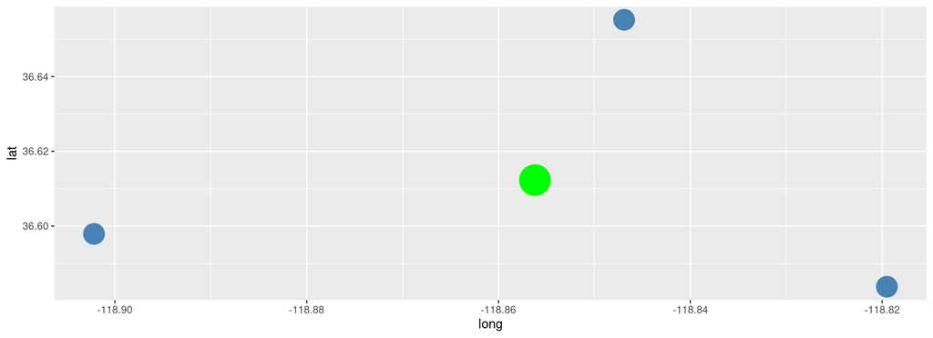

```r
library(ggplot2)

ggplot(outposts, aes(x = long, y = lat)) +
  geom_point(size = 8, color = "steelblue") +
  geom_point(data = land_pad,
             aes(x = long, y = lat),
             size = 12,
             color = "green")
```

**That’s looking good, but…**

We’re going to need to be very precise to land perfectly in between these outposts. To make our captain really happy, let’s put this all in an interactive zoomable map. For interactive maps we use **leaflet**.

# Leaflet maps

### The `leaflet` package.

[figure not shown]

Leaflet makes interactive maps easy and you build them up in layers similar to a ggplot.

### Install `leaflet`

```r
install.packages("leaflet")
```

> Explore the [Full Leaflet Guide!](https://rstudio.github.io/leaflet/)

## Maps that zoom

Leaflet builds map with layers similar to ggplot, but instead of adding things with the `+`, leaflet adds new layers with the `%>%` (“the pipe”).

### 1. Start with the outpost coordinates

```r
library(leaflet)

leaflet(outposts) %>%
  addCircles(radius = 250) %>%
  addTiles()
```

```
## Assuming "long" and "lat" are longitude and latitude, respectively
```

[interactive chart not shown]

### 2. Add the landing site

*Fingers crossed it’s in the middle….*

```r
leaflet(outposts) %>%
  addCircles(radius = 300) %>%
  addTiles() %>%
  addMarkers(data = land_pad)  #<<
```

### 3. Add labels

*Try hovering over one of the outposts to see its label.*

```r
leaflet(outposts) %>%
  addCircles(radius = 300,
             label = ~ID) %>%   #<<
  addTiles() %>%
  addMarkers(data  = land_pad,
             label = "Land HERE!",  #<<
             labelOptions = labelOptions(noHide = TRUE))  #<<
```

```
## Assuming "long" and "lat" are longitude and latitude, respectively
## Assuming "long" and "lat" are longitude and latitude, respectively
```

[interactive chart not shown]

### Explore!

News just came in that the outposts will soon be upgrading their **radar** to detect ships up to `4,200 meters` away. Will that be a problem?

**Steps**

1. Update the radius argument in `addCircles(...)` to be equal to `4200`.
2. Add the argument `, fillColor = "yellow"` inside `addCircles(..)`

**Show code**

```r
leaflet(outposts) %>%
  addCircles(radius = 4200, #<<
             label = ~ID,
             fillColor = "yellow") %>%
  addTiles() %>%
  addMarkers(data  = land_pad,
             label = "Land HERE!",
             labelOptions = labelOptions(noHide = TRUE))
```

> **Will our landing spot still be safe?**

## Woah! That’s a close one.

You’re on 🔥 fire data droid. Let’s sit here a minute to cool down…

Ok, now let’s go land on that planet before we get stuck up here with permanent space legs.

### Yoda says

[figure not shown]

**BASEMAPS.** There are lots of options for basemaps in leaflet. One of my favorites is `CartoDB.Positron` because its greyness doesn’t distract from the data.

Add it to your map by swapping out `addTiles()` for `addProviderTiles(providers$CartoDB.Positron)`

**Show code**

```r
leaflet(outposts) %>%
  addCircles(radius = 4200,
             label = ~ID,
             fillColor = "yellow") %>%
   addProviderTiles(providers$CartoDB.Positron) %>%  #<<
   addMarkers(data  = land_pad,
              label = "Land HERE!",
              labelOptions = labelOptions(noHide = TRUE))
```

See MORE examples of basemaps here: https://rstudio.github.io/leaflet/basemaps.html

And explore the [Full Leaflet Guide!](https://rstudio.github.io/leaflet/)